# QMSS-4015-Lab-1

Gregory M. Eirich

September 12, 2017

## Lab 1

due Sept 27th based on data from here: http://www.thearda.com/Archive/Files/Codebooks/GSS2006_CB.asp

go line-by-line through this code; otherwise you might miss something

```r
setwd("/Users/gregoryeirich/Downloads")
gss = read.csv("GSS.2006.csv.xls")
```

```r
names(gss) ## what variables are in here? "vpsu" and "vstrat" etc.
```

```
##    [1] "vpsu"     "vstrat"   "adults"   "ballot"   "dateintv" "famgen"
##    [7] "form"     "formwt"   "gender1"  "hompop"   "id"       "intage"
##   [13] "intid"    "intyrs"   "mode"     "oversamp" "phase"    "race"
##   [19] "reg16"    "region"   "relate1"  "relhh1"   "relhhd1"  "respnum"
##   [25] "rvisitor" "sampcode" "sample"   "sex"      "size"     "spaneng"
##   [31] "srcbelt"  "version"  "visitors" "wtss"     "wtssall"  "wtssnr"
##   [37] "xnorcsiz" "year"     "hispanic" "rplace"   "degree"   "hefinfo"
##   [43] "wrkstat"  "racecen1" "marital"  "phone"    "comprend" "coop"
##   [49] "feeused"  "hhrace"   "lngthinv" "educ"     "childs"   "ethnum"
##   [55] "age"      "cohort"   "intrace1" "attend"   "inthisp"  "hhtype"
##   [61] "hhtype1"  "earnrs"   "whoelse6" "whoelse1" "whoelse2" "whoelse3"
##   [67] "whoelse4" "whoelse5" "partyid"  "relig"    "teens"    "preteen"
##   [73] "babies"   "reliten"  "dwelling" "vote04"   "mar1"     "zodiac"
##   [79] "old1"     "fund"     "polviews" "income"   "income06" "wrkslf"
##   [85] "isco681"  "isco88"   "occ80"    "prestg80" "wrkgovt"  "sei"
```

[output cut: 196 more lines]

```r
##View(gss) ## look at it as a spreadsheet
```

## 1- Use the table command, summary or describe commands, to tabulate one variable; and explain your results.

**How about I investigate something with work-life conflict?**

```r
table(gss$jbintfam) ## tabulates "How often do you feel that the demands of your job interfere with your family life?"
```

```
##
##   1   2   3   4   5
##  51 101 364 293 206
```

if I look up JBINTFAM at www.thearda.com above, I see that 1 = Always, and 5 = Never; there are 206 5’s and only 51 1’s

```r
summary(gss$jbintfam) ## calculates this variable on a 1-5 scale; not as helpful
```

```
##    Min. 1st Qu.  Median    Mean 3rd Qu.    Max.    NA's
##   1.000   3.000   3.000   3.495   4.000   5.000    3495
```

```r
prop.table(table(gss$jbintfam)) ## this gives us the proportions for this variable
```

```
##
##          1          2          3          4          5
## 0.05024631 0.09950739 0.35862069 0.28866995 0.20295567
```

```r
options(digits=2) ## what if I think those proportions are ugly?  Shorten them.

prop.table(table(gss$jbintfam)) ## this gives us the proportions for this variable
```

```
##
##    1    2    3    4    5
## 0.05 0.10 0.36 0.29 0.20
```

seeing this as a proportion helps a bit: ony 5% are Always feeling interfered with, while 20% are Never feeling interfered with

```r
options(digits=7) ## what if I want to get back to my original level.  Default is 7.
```

```r
##install.packages("psych")  ## install this package, if you haven't already
library(psych) ## this brings into your R session
```

```r
describe(gss$wrkstat) ## this summarizes "Last week were you working full-time, part-time, going to school, keeping house, or what?" as if it were a number; this is not something you'd normally do
```

```
##    vars    n mean   sd median trimmed mad min max range skew kurtosis   se
## X1    1 4506 2.93 2.39      1    2.62   0   1   8     7 0.77    -0.99 0.04
```

```r
table(gss$wrkstat) ## Ahh, that's better: a table of categories: we see that 2322 people work full-time, for instance.
```

```
##
##    1    2    3    4    5    6    7    8
## 2322  440   90  148  715  140  496  155
```

```r
describe(gss$hrs1) ## this works better for a numeric variable like "IF WORKING, FULL OR PART TIME: How many hours did you work last week, at all jobs?".  The mean is 42.08.
```

```
##    vars    n  mean    sd median trimmed mad min max range skew kurtosis
## X1    1 2739 42.08 14.23     40   42.06 8.9   1  89    88  0.2     1.27
##      se
## X1 0.27
```

## 2. Using either the plyr or doBy commands, compare the means and standard deviations for one variable, for at least two subgroups and explain your results.

```r
##install.packages("plyr")  ## install this package, if you haven't already
library(plyr)
```

```r
ddply(gss, "jbintfam", summarise, Mean = mean(hrs1, na.rm = T), SD = sd(hrs1, na.rm = T))
```

```
##   jbintfam     Mean       SD
## 1        1 49.95556 18.32033
## 2        2 46.33696 10.93766
## 3        3 44.54094 13.05469
## 4        4 39.89416 11.51491
## 5        5 38.34555 13.14878
## 6       NA 41.92089 14.76669
```

ddply’s results show that Always work 49.95 hours, while Nevers work 38.34 hours, with everyone else monotonically related.

```r
##install.packages("doBy")  ## install this package, this is going to do the same thing as using plyr above
library(doBy)
```

```r
summaryBy(hrs1~jbintfam, data=gss, FUN=c(mean, sd), na.rm=T) ## same result as above when using plyr; just another way
```

```
##   jbintfam hrs1.mean  hrs1.sd
## 1        1  49.95556 18.32033
## 2        2  46.33696 10.93766
## 3        3  44.54094 13.05469
## 4        4  39.89416 11.51491
## 5        5  38.34555 13.14878
## 6       NA  41.92089 14.76669
```

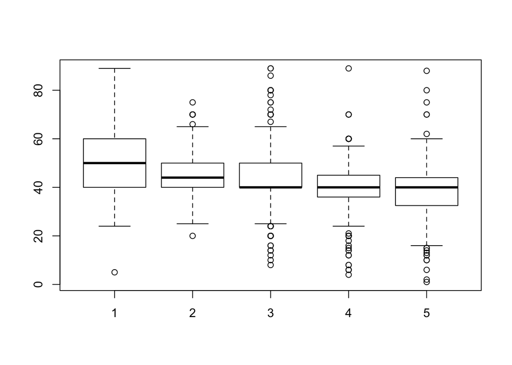

```r
boxplot(hrs1~jbintfam, data=gss) ## graphically displays the relationship in boxplot form
```

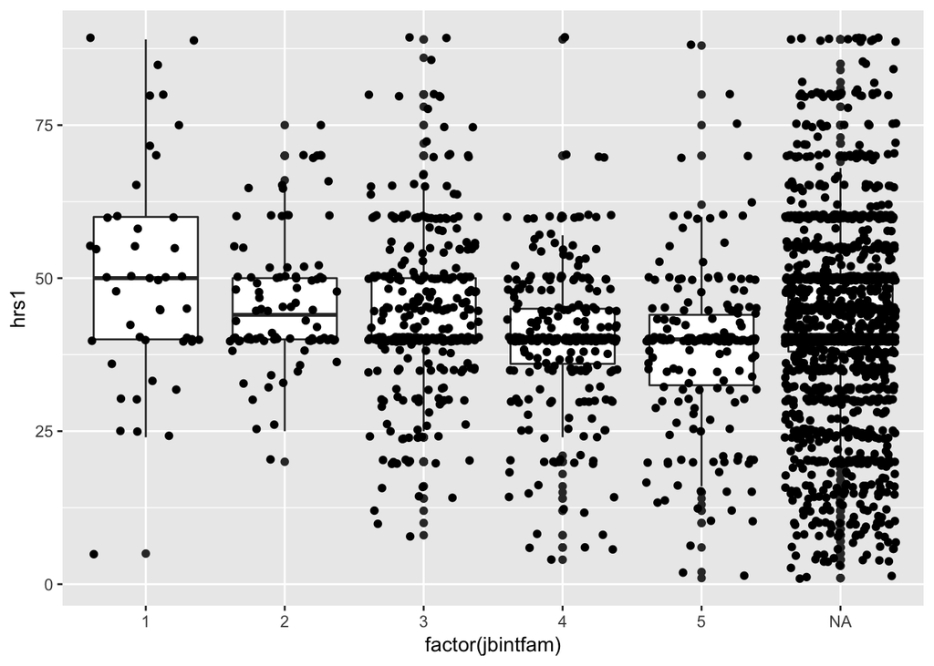

```r
##install.packages("ggplot2") ## this program will make a fancy boxplot instead; same results as above
library(ggplot2)
p = ggplot(gss, aes(factor(jbintfam), hrs1))
p + geom_boxplot() + geom_jitter()
```

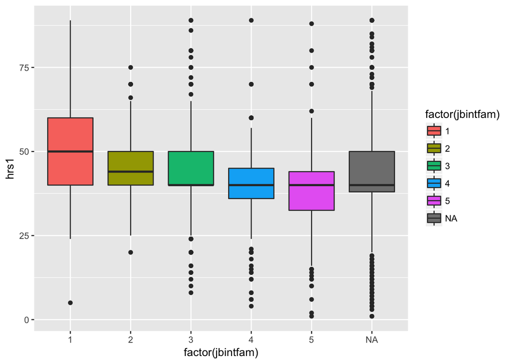

```r
p + geom_boxplot(aes(fill = factor(jbintfam))) ## see how they include the NAs, which are the missings
```

## 3. Using the gmodels or another command, crosstabulate two categorical or ordinal variables (getting proportions); and explain your results

```r
##install.packages("gmodels")  ## install this package, if you haven't already
library(gmodels)
```

```r
CrossTable(gss$jbintfam, gss$wrkstat, prop.r=F, prop.c=T, prop.t=F, prop.chisq=F, format="SPSS") ## this generates how frequently different types of workers feel interference between family and work
```

```
##
##    Cell Contents
## |-------------------------|
## |                   Count |
## |          Column Percent |
## |-------------------------|
##
## Total Observations in Table:  1015
##
##              | gss$wrkstat
## gss$jbintfam |        1  |        2  |        3  |        4  |        5  |        6  |        7  |        8  | Row Total |
## -------------|-----------|-----------|-----------|-----------|-----------|-----------|-----------|-----------|-----------|
##            1 |       40  |        7  |        2  |        0  |        0  |        1  |        1  |        0  |       51  |
##              |    4.914% |    5.147% |    6.897% |    0.000% |    0.000% |   11.111% |    6.250% |    0.000% |           |
## -------------|-----------|-----------|-----------|-----------|-----------|-----------|-----------|-----------|-----------|
##            2 |       89  |        5  |        3  |        1  |        0  |        1  |        2  |        0  |      101  |
##              |   10.934% |    3.676% |   10.345% |   33.333% |    0.000% |   11.111% |   12.500% |    0.000% |           |
## -------------|-----------|-----------|-----------|-----------|-----------|-----------|-----------|-----------|-----------|
##            3 |      304  |       38  |       11  |        1  |        0  |        4  |        4  |        2  |      364  |
##              |   37.346% |   27.941% |   37.931% |   33.333% |    0.000% |   44.444% |   25.000% |   28.571% |           |
## -------------|-----------|-----------|-----------|-----------|-----------|-----------|-----------|-----------|-----------|
##            4 |      232  |       43  |       11  |        0  |        0  |        2  |        3  |        2  |      293  |
##              |   28.501% |   31.618% |   37.931% |    0.000% |    0.000% |   22.222% |   18.750% |   28.571% |           |
## -------------|-----------|-----------|-----------|-----------|-----------|-----------|-----------|-----------|-----------|
##            5 |      149  |       43  |        2  |        1  |        1  |        1  |        6  |        3  |      206  |
##              |   18.305% |   31.618% |    6.897% |   33.333% |  100.000% |   11.111% |   37.500% |   42.857% |           |
## -------------|-----------|-----------|-----------|-----------|-----------|-----------|-----------|-----------|-----------|
## Column Total |      814  |      136  |       29  |        3  |        1  |        9  |       16  |        7  |     1015  |
##              |   80.197% |   13.399% |    2.857% |    0.296% |    0.099% |    0.887% |    1.576% |    0.690% |           |
## -------------|-----------|-----------|-----------|-----------|-----------|-----------|-----------|-----------|-----------|
##
##
```